# Statistical Learning and Data Analysis - Lab 1

Bar Weinstein And Hananel Giat

March 31, 2019

## 1 - **Graph Critique**

1. Both graphs try to demonstrate the patterns and distrubition of flights deprature delays. The graphs try to show that departure delays, from a sample airpot (DEN), depends on the location of the flight location and on the cyclical factor that occurs during the years, i.e. holidays, and random non-expected factors, i.e. economic recession.
2. They answer it partialy. The first graph is dense with colors and not easy to interpret, but if you look at it closely you can see the “probleamtic” airport, airports which has large flights delays. The second graph is a more general one, it shows the large delays versus the cyclical pattern of total flights, it shows (almost clearly) that late/large delays not always correlated with the cyclical pattern of total flights, in example they subject to random variation.
3. yes, for example is only DEN airport has large delays to red color (> 25%) airpots or is it a general issue with the destination airport?. is large delays cluster? does large delays in a earlier periods imply large delays in the subsequent one? 4.Add the distribution of flighs delay (or only right tails delays) of DEN airport or to each airport in addition to percentage outlook. Add analysis of total flights Vs large delays AFTER removing seasonality from all flights variable.

## 2 - **Reproducing these analyses**

### *First Graph*

For this graph we need to extract the total number of flights (departures) per day and the total late delay (>15) per day. first we mutate a new variable which represnt the daily date, then we build a new tibble which has information about the aforementioned variables. we didn’t remove any outliers from the data because we didn’t had any information about the right tail values of `dep_delays` (if they are extreme values or not-relevant one), In addition there is in the original `flights` data a few observation without departure delay data so the late delay variable may be biased (downwards or upwards).

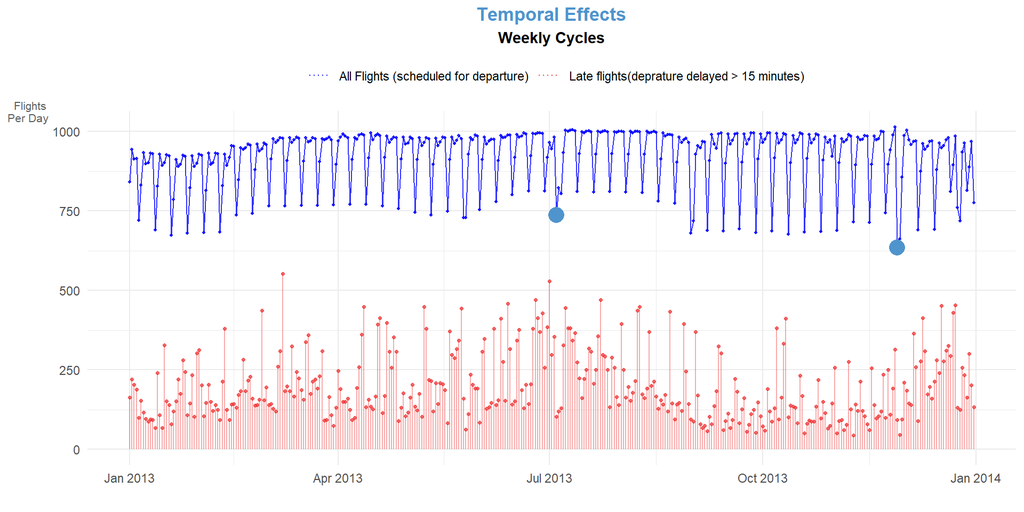

### *Second Graph*

To produce the following we had to used both the `flights` and the `airports` data frames to fit each arrow to correct location of each airport. after we did that we used the `map_data` function (from ggplot2) to have a USA map and Countries names. before plotting the graph we had to make a categorical variable grouping the `late_delays` variable to sub-group (the same as in the poster). after the data wrangling and getting the map data we combine it all together using ggplot2 to make the following graph.

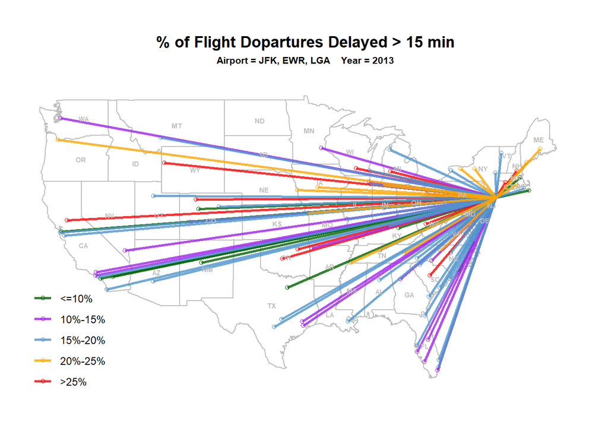

## 3 - **Freestyle analysis**

Untill now we’ve looked at the `dep_delay` per Airport. There is reason to bielive that each Airline (carrier) has different `dep_delay` distrubtion (El-Al is famous in their delays!). To make the comparsion more clear we trimmed the lowest and highest 1% observations for each Carrier (i.e. we kept $quantile(0.01,0.99)$)

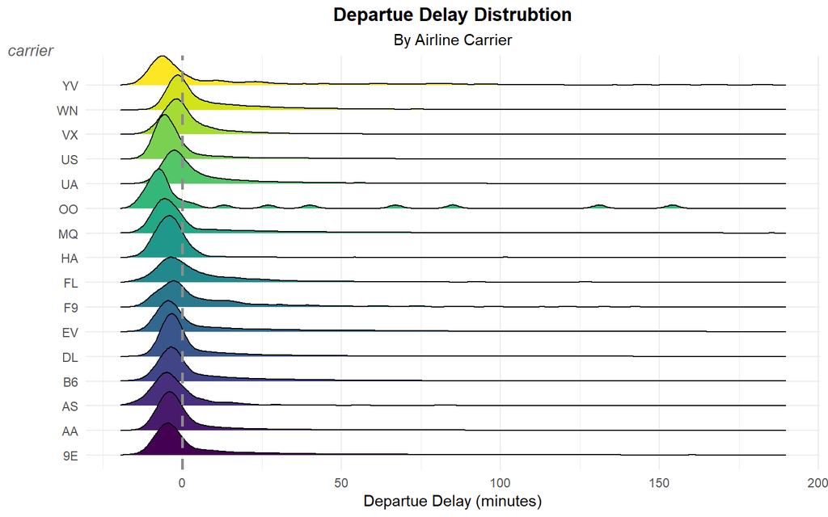

There is a few interesting conclusion that can be drawn from the graph:

1. All Airline Carriers have distrubtion mode (most frequent value) smaller than 0! - That means that most of departure delays of each Airline are actually Departures that left early than planned.
2. Most Airline Carriers have bell-curve like distrubtion (with a few exception with fat tails), that means that most of the flights occur according to plan (departure delay close to 0)
3. The most interesting thing, in our opionion, is the fact that extreme (positive) departure delays occur by a few companies (see $OO$). Even though almost all Carriers has signifcant right fat tail (compare to gaussian), a few Carriers can explain most of the largest delays. than can imply that airports that work alot with specific Carrier can have their values (depicit in early sections) biased because of the Carrier. We suggest that further analysis regarding Departures Delays will include seperation of Airline Carriers for accurate results.
4. The odd behaviour of the departure delays in the right tails of the distrubtion can imply a power-law (pareto) distrubtion of the (right) tails.

## 4 - **Graphical Lineup**

First let’s look the original data

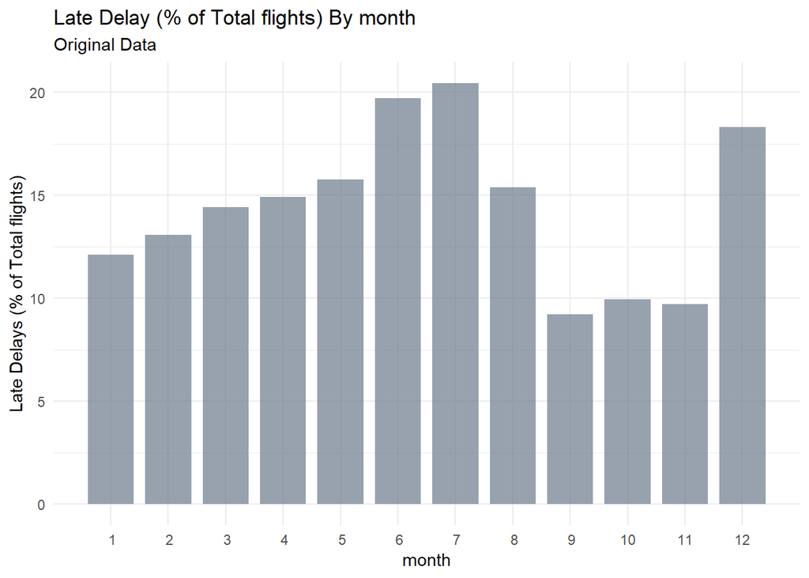

We can clearly see there is a different in the original data in the *Late delay* (as percentage of total flights) by *month*. Even after normalizing the *Late Delay* variable by the total flights at the specific month (adjusting to volume) we can observe a difference between the months.

Now we’ll use some randomazition (bootstrap) to check the next hypothesis:

$$H_0: Average \quad flight \quad delay \quad may \quad change \quad per \quad month \quad \\
H_1: Otherwise \quad (i.e. \quad month \quad doesn't \quad effect \quad delays)$$

- If the Null Hypothesis is *correct* we’re going to see different results for each bootstrap simulation (different pattern for each simulation which include a cyclical change)
- If the Null Hypothesis is *false* we’re going to see similar results for each bootstrap simulation (evenly spread bars)

Now for the results:

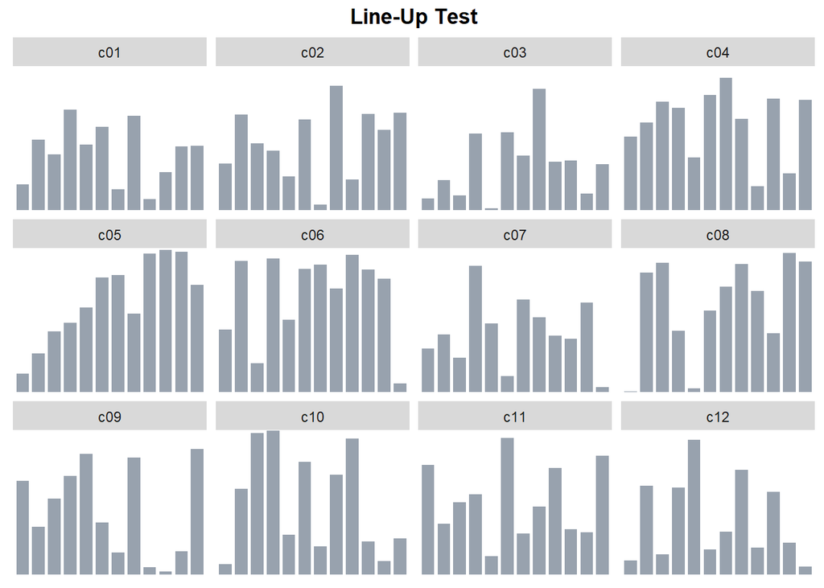

**Remarks**:

1. There is a big difference between each simulation.
2. There isn’t an evenly spread results (per month).
3. Each simulation produce results highlighting a different months as the “*bad*” one.

**Conclusion**:

We checked the hypothesis that average flight delay may change per month. To check it we looked at relative values of late delays (% of total flights per month) and randomized (sort of bootstraping) the months values to see if the differences between months remain. The results imply that the Null Hypothesis is **correct** - *Late Flights Delay* does change per month!